# DetectAI: Sistema Preditivo de Antifraude - Previsão com Regressão Logica e Floresta Aleatoria

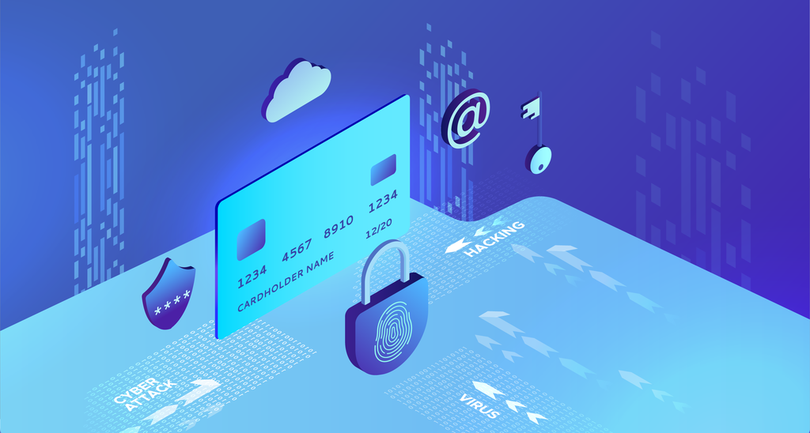

# DetectAI: Sistema Preditivo de Antifraude - Previsão com Regressão Logica e Floresta Aleatoria

## Resumo

O projeto DetectAI visa desenvolver um sistema preditivo de antifraude que integra técnicas de Inteligência Artificial (IA) para identificar transações financeiras fraudulentas. A abordagem utilizada concentra-se na aplicação de algoritmos de aprendizado de máquina para a detecção de padrões anômalos, em conformidade com as características de dados transacionais históricos.

## Introdução

A fraude financeira é uma preocupação crescente no setor financeiro, representando perdas significativas para instituições e indivíduos. Com a digitalização das operações financeiras, torna-se imperativo implementar soluções eficientes e automatizadas para a detecção precoce de fraudes. O DetectAI propõe um sistema baseado em IA para fortalecer as medidas de segurança e prevenção.

## Objetivos

- Desenvolver um modelo de IA capaz de identificar transações fraudulentas com alta precisão e baixa taxa de falsos positivos.
- Analisar a viabilidade do sistema em ambientes de processamento de alto volume de transações.
- Avaliar o desempenho do modelo em diferentes cenários e tipos de dados.

## Metodologia

A metodologia envolve várias etapas, incluindo a coleta de dados, pré-processamento, seleção de características, modelagem, validação cruzada e avaliação. Utilizaremos o conjunto de dados público "Credit Card Fraud Detection" da plataforma Kaggle como base para treinamento e teste do modelo. Técnicas de balanceamento de classes serão aplicadas para lidar com o desequilíbrio intrínseco dos dados. Algoritmos como Regressão Logística, Floresta Aleatória e Redes Neurais serão explorados e comparados.

## Resultados Esperados

Antecipa-se que o DetectAI será capaz de detectar fraudes com uma eficácia superior em comparação a sistemas baseados em regras ou métodos estatísticos tradicionais. As métricas de avaliação incluirão a acurácia, recall, F1-score e a área sob a curva ROC.

## Conclusão

O DetectAI visa estabelecer um marco no campo da segurança financeira, contribuindo para a literatura acadêmica e oferecendo implicações práticas para instituições financeiras. Espera-se que o sistema possa ser integrado como uma ferramenta de suporte na identificação e prevenção de atividades fraudulentas em tempo real.

## Palavras-chave

Detecção de Fraudes, Inteligência Artificial, Aprendizado de Máquina, Segurança Financeira, Análise Preditiva.

## Detalhamento dos Dados do Conjunto de Dados de Fraude em Cartões de Crédito

### Contexto

É crucial para as empresas de cartões de crédito reconhecer transações fraudulentas para evitar cobranças indevidas aos seus clientes. Este conjunto de dados fornece uma base para desenvolver e avaliar sistemas de detecção de fraudes.

### Conteúdo

- O conjunto de dados consiste em transações realizadas com cartões de crédito em setembro de 2013 por portadores de cartões europeus.
- Ele contém 284.807 transações ao longo de dois dias, das quais 492 são fraudes, representando 0,172% do total de transações.
- Os dados são altamente desbalanceados, o que é um desafio comum em aplicações de detecção de fraude.

### Variáveis

- As variáveis numéricas **V1 a V28** são componentes principais resultantes de uma transformação PCA, utilizada para proteger informações confidenciais.
- A variável **'Time'** representa os segundos decorridos entre cada transação e a primeira transação no conjunto de dados.
- A variável **'Amount'** é o montante da transação, que pode ser usado para aprendizado sensível ao custo dependente do exemplo.
- A variável de resposta **'Class'** indica se a transação é fraudulenta (`1`) ou legítima (`0`).

### Recomendações de Avaliação

- Devido ao desequilíbrio das classes, a precisão da matriz de confusão não é significativa. Recomenda-se utilizar a Área Sob a Curva Precision-Recall (AUPRC) para medir a precisão.

### Agradecimentos

- Os dados foram coletados e analisados durante uma colaboração de pesquisa entre a Worldline e o Grupo de Aprendizado de Máquina da ULB (Université Libre de Bruxelles).

### Citações Relevantes

- Trabalhos de Andrea Dal Pozzolo, Olivier Caelen, e outros que se concentraram em calibrar a probabilidade com subamostragem para classificação desequilibrada, estratégias de aprendizado para detecção de fraude em cartões de crédito e a combinação de aprendizado não supervisionado e supervisionado em detecção de fraude.

### Estatísticas Descritivas do Conjunto de Dados

```
plaintext
- Número de transações: 284.807
- Fraudes: 492 (0,172% do total)
- Variáveis de entrada: Somente numéricas, resultado de uma transformação PCA
- Variáveis não transformadas: 'Time' e 'Amount'
- Variável de resposta: 'Class' (1 para fraude, 0 para não fraude)
- Intervalo de tempo: Segundos decorridos desde a primeira transação no conjunto de dados
- Montante da transação: Pode variar de 0 a 25.691,16
```

## Fonte de Dados

Kaggle: [Credit Card Fraud Detection](https://www.kaggle.com/datasets/mlg-ulb/creditcardfraud)

Estudo feito por

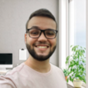

## Vinicius Santos

[Linkedin](https://www.linkedin.com/in/vinicius-souza-santoss/)

[Github](https://github.com/ViniciusKanh)

# Amostra dos Dados

```python
df.head()
```

[output not shown]

5 rows × 31 columns

Este conjunto de dados é fundamental para o desenvolvimento do sistema DetectAI, um modelo de detecção de fraude em cartões de crédito. O modelo foi treinado para identificar padrões de transações fraudulentas com base nas variáveis numéricas resultantes da PCA e nas características 'Time' e 'Amount'. Com uma abordagem sofisticada de aprendizado de máquina, o DetectAI tem como objetivo reduzir significativamente as taxas de falsos positivos e negativos, proporcionando uma segurança para os portadores de cartões de crédito.

## Entendendo os Componentes Principais V1 a V28 no Conjunto de Dados

Os termos `V1` a `V28` no conjunto de dados de fraude em cartões de crédito são componentes principais obtidos através da Análise de Componentes Principais (PCA). Esta seção detalha o que são esses componentes e sua importância no modelo de detecção de fraude.

### PCA (Análise de Componentes Principais)

- **Definição**: PCA é uma técnica estatística usada para transformar dados com muitas variáveis em um conjunto menor de variáveis (componentes principais) que ainda contém a maior parte da informação original.
- **Objetivo**: Reduzir a dimensionalidade dos dados, mantendo o máximo de variação possível.
- **Vantagens**: Identifica padrões nos dados, reduz a complexidade dos dados, e ajuda na anonimização e proteção de informações confidenciais.

### Propriedades dos Componentes Principais (V1-V28)

- **Não Correlacionados**: Cada componente (V1-V28) é independente dos outros, representando diferentes aspectos dos dados.
- **Ordenados**: Ordenados por importância, com V1 representando a maior variação, seguido por V2, e assim por diante.
- **Redução de Dimensionalidade**: Auxilia na simplificação dos dados sem perder informações significativas.
- **Anonimização de Dados**: Em contextos sensíveis, como transações financeiras, a PCA transforma dados confidenciais em um formato não identificável.

### Uso em Detecção de Fraude

- **Modelagem de Dados**: A PCA transforma as características originais em componentes que são usados para treinar modelos de detecção de fraude.
- **Preservação da Privacidade**: As variáveis originais são transformadas para proteger as informações dos clientes.
- **Identificação de Padrões**: Os modelos de aprendizado de máquina usam esses componentes para identificar padrões que distinguem transações fraudulentas das legítimas.

Em resumo, os componentes `V1` a `V28` são fundamentais para entender a estrutura dos dados e para construir um modelo eficaz de detecção de fraude, mantendo ao mesmo tempo a confidencialidade e a segurança das informações do portador do cartão.

```python
from google.colab import drive
drive.mount('/content/drive')
```

## Pré Processamento

Importação das Bibliotecas e Carregamento dos Dados

```python
import pandas as pd
import numpy as np
from sklearn.model_selection import train_test_split
from sklearn.preprocessing import StandardScaler

# Substitua 'caminho_do_arquivo.csv' pelo caminho do seu arquivo
caminho_do_arquivo = '/content/drive/My Drive/0-Dataset/creditcard.csv'
df = pd.read_csv(caminho_do_arquivo)
```

Análise Exploratória Básica

```python
# Visualizando as primeiras linhas do DataFrame
print(df.head())

# Resumo estatístico dos dados
print(df.describe())

# Verificar se há valores ausentes
print(df.isnull().sum())
```

```
   Time        V1        V2        V3        V4        V5        V6        V7  \
0   0.0 -1.359807 -0.072781  2.536347  1.378155 -0.338321  0.462388  0.239599
1   0.0  1.191857  0.266151  0.166480  0.448154  0.060018 -0.082361 -0.078803
2   1.0 -1.358354 -1.340163  1.773209  0.379780 -0.503198  1.800499  0.791461
3   1.0 -0.966272 -0.185226  1.792993 -0.863291 -0.010309  1.247203  0.237609
4   2.0 -1.158233  0.877737  1.548718  0.403034 -0.407193  0.095921  0.592941

         V8        V9  ...       V21       V22       V23       V24       V25  \
0  0.098698  0.363787  ... -0.018307  0.277838 -0.110474  0.066928  0.128539
1  0.085102 -0.255425  ... -0.225775 -0.638672  0.101288 -0.339846  0.167170
2  0.247676 -1.514654  ...  0.247998  0.771679  0.909412 -0.689281 -0.327642
3  0.377436 -1.387024  ... -0.108300  0.005274 -0.190321 -1.175575  0.647376
4 -0.270533  0.817739  ... -0.009431  0.798278 -0.137458  0.141267 -0.206010

        V26       V27       V28  Amount  Class
0 -0.189115  0.133558 -0.021053  149.62      0
1  0.125895 -0.008983  0.014724    2.69      0
2 -0.139097 -0.055353 -0.059752  378.66      0
3 -0.221929  0.062723  0.061458  123.50      0
4  0.502292  0.219422  0.215153   69.99      0

[5 rows x 31 columns]
                Time            V1            V2            V3            V4  \
count  284807.000000  2.848070e+05  2.848070e+05  2.848070e+05  2.848070e+05
mean    94813.859575  1.168375e-15  3.416908e-16 -1.379537e-15  2.074095e-15
std     47488.145955  1.958696e+00  1.651309e+00  1.516255e+00  1.415869e+00
min         0.000000 -5.640751e+01 -7.271573e+01 -4.832559e+01 -5.683171e+00
25%     54201.500000 -9.203734e-01 -5.985499e-01 -8.903648e-01 -8.486401e-01
50%     84692.000000  1.810880e-02  6.548556e-02  1.798463e-01 -1.984653e-02
75%    139320.500000  1.315642e+00  8.037239e-01  1.027196e+00  7.433413e-01
max    172792.000000  2.454930e+00  2.205773e+01  9.382558e+00  1.687534e+01

                 V5            V6            V7            V8            V9  \
count  2.848070e+05  2.848070e+05  2.848070e+05  2.848070e+05  2.848070e+05
mean   9.604066e-16  1.487313e-15 -5.556467e-16  1.213481e-16 -2.406331e-15
std    1.380247e+00  1.332271e+00  1.237094e+00  1.194353e+00  1.098632e+00
min   -1.137433e+02 -2.616051e+01 -4.355724e+01 -7.321672e+01 -1.343407e+01
25%   -6.915971e-01 -7.682956e-01 -5.540759e-01 -2.086297e-01 -6.430976e-01
50%   -5.433583e-02 -2.741871e-01  4.010308e-02  2.235804e-02 -5.142873e-02
75%    6.119264e-01  3.985649e-01  5.704361e-01  3.273459e-01  5.971390e-01
```

[output cut: 50 more lines]

```
V17       0
V18       0
V19       0
V20       0
V21       0
V22       0
V23       0
V24       0
V25       0
V26       0
V27       0
V28       0
Amount    0
Class     0
dtype: int64
```

Pré-processamento dos Dados

```python
# Normalizando as colunas 'Time' e 'Amount'
scaler = StandardScaler()
df['NormalizedAmount'] = scaler.fit_transform(df[['Amount']])
df['NormalizedTime'] = scaler.fit_transform(df[['Time']])

# Removendo as colunas originais 'Time' e 'Amount'
df = df.drop(['Time', 'Amount'], axis=1)

# Separando as características e o alvo
X = df.drop('Class', axis=1)
y = df['Class']
```

Divisão em Conjunto de Treino e Teste

```python
# Dividindo os dados em treino e teste
X_train, X_test, y_train, y_test = train_test_split(X, y, test_size=0.3, random_state=42)
```

# Analise Exploratoria

```python
# Análise Exploratória de Dados Básica
print("Descrição Estatística:\n", df.describe())
print("\nContagem de Classes:\n", df['Class'].value_counts())
print("\nValores Ausentes:\n", df.isnull().sum())
```

```
Descrição Estatística:
                  V1            V2            V3            V4            V5  \
count  2.848070e+05  2.848070e+05  2.848070e+05  2.848070e+05  2.848070e+05
mean   1.168375e-15  3.416908e-16 -1.379537e-15  2.074095e-15  9.604066e-16
std    1.958696e+00  1.651309e+00  1.516255e+00  1.415869e+00  1.380247e+00
min   -5.640751e+01 -7.271573e+01 -4.832559e+01 -5.683171e+00 -1.137433e+02
25%   -9.203734e-01 -5.985499e-01 -8.903648e-01 -8.486401e-01 -6.915971e-01
50%    1.810880e-02  6.548556e-02  1.798463e-01 -1.984653e-02 -5.433583e-02
75%    1.315642e+00  8.037239e-01  1.027196e+00  7.433413e-01  6.119264e-01
max    2.454930e+00  2.205773e+01  9.382558e+00  1.687534e+01  3.480167e+01

                 V6            V7            V8            V9           V10  \
count  2.848070e+05  2.848070e+05  2.848070e+05  2.848070e+05  2.848070e+05
mean   1.487313e-15 -5.556467e-16  1.213481e-16 -2.406331e-15  2.239053e-15
std    1.332271e+00  1.237094e+00  1.194353e+00  1.098632e+00  1.088850e+00
min   -2.616051e+01 -4.355724e+01 -7.321672e+01 -1.343407e+01 -2.458826e+01
25%   -7.682956e-01 -5.540759e-01 -2.086297e-01 -6.430976e-01 -5.354257e-01
50%   -2.741871e-01  4.010308e-02  2.235804e-02 -5.142873e-02 -9.291738e-02
75%    3.985649e-01  5.704361e-01  3.273459e-01  5.971390e-01  4.539234e-01
max    7.330163e+01  1.205895e+02  2.000721e+01  1.559499e+01  2.374514e+01

       ...           V22           V23           V24           V25  \
count  ...  2.848070e+05  2.848070e+05  2.848070e+05  2.848070e+05
mean   ... -3.568593e-16  2.578648e-16  4.473266e-15  5.340915e-16
std    ...  7.257016e-01  6.244603e-01  6.056471e-01  5.212781e-01
min    ... -1.093314e+01 -4.480774e+01 -2.836627e+00 -1.029540e+01
25%    ... -5.423504e-01 -1.618463e-01 -3.545861e-01 -3.171451e-01
50%    ...  6.781943e-03 -1.119293e-02  4.097606e-02  1.659350e-02
75%    ...  5.285536e-01  1.476421e-01  4.395266e-01  3.507156e-01
max    ...  1.050309e+01  2.252841e+01  4.584549e+00  7.519589e+00

                V26           V27           V28          Class  \
count  2.848070e+05  2.848070e+05  2.848070e+05  284807.000000
mean   1.683437e-15 -3.660091e-16 -1.227390e-16       0.001727
std    4.822270e-01  4.036325e-01  3.300833e-01       0.041527
min   -2.604551e+00 -2.256568e+01 -1.543008e+01       0.000000
25%   -3.269839e-01 -7.083953e-02 -5.295979e-02       0.000000
50%   -5.213911e-02  1.342146e-03  1.124383e-02       0.000000
75%    2.409522e-01  9.104512e-02  7.827995e-02       0.000000
max    3.517346e+00  3.161220e+01  3.384781e+01       1.000000
```

[output cut: 36 more lines]

```
V18                 0
V19                 0
V20                 0
V21                 0
V22                 0
V23                 0
V24                 0
V25                 0
V26                 0
V27                 0
V28                 0
Class               0
NormalizedAmount    0
NormalizedTime      0
dtype: int64
```

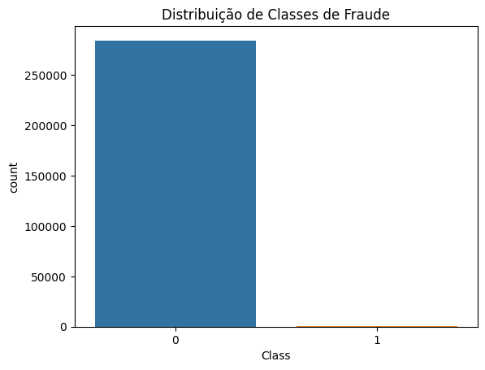

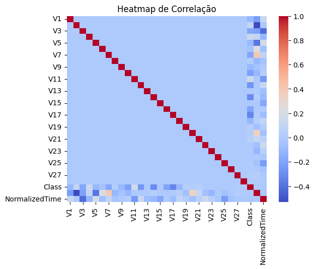

```python
# Visualizações
import matplotlib.pyplot as plt
import seaborn as sns

sns.countplot(x='Class', data=df)
plt.title('Distribuição de Classes de Fraude')
plt.show()

sns.heatmap(df.corr(), cmap='coolwarm')
plt.title('Heatmap de Correlação')
plt.show()
```

**Desequilíbrio de Classe:** O gráfico confirma que o conjunto de dados é altamente desequilibrado, com uma grande maioria de transações sendo legítimas e apenas uma pequena minoria sendo fraudulentas. Isso é consistente com a realidade, onde as transações fraudulentas são, felizmente, raras em comparação com as transações legítimas.

## Desafios na Modelagem:

**Aprendizado Inclinado:** Modelos de aprendizado de máquina podem ficar tendenciosos em direção à classe majoritária, o que pode resultar em um desempenho inadequado na detecção da classe minoritária (fraudes), que é o foco do projeto.

**Avaliação de Desempenho:** Métricas convencionais de avaliação, como acurácia, podem ser enganosas. Uma alta acurácia pode simplesmente refletir a capacidade do modelo de prever a classe majoritária, enquanto falha em detectar a classe de interesse (fraudes). Estratégias de Mitigação:

**Reamostragem: **Técnicas de reamostragem, como sobreamostragem da classe minoritária ou subamostragem da classe majoritária, podem ser usadas para equilibrar o conjunto de dados antes do treinamento.

**Ponderação de Classes:** Atribuir pesos diferentes às classes durante o treinamento do modelo para enfatizar a importância da classe minoritária. Métricas Apropriadas: Utilizar métricas que são mais informativas para conjuntos de dados desequilibrados, como a Área sob a Curva de Precisão-Recall (AUPRC), precisão, recall e pontuação F1. Impacto no Projeto:

```
  O projeto deve priorizar a detecção precisa de transações fraudulentas, mesmo que isso possa resultar em um aumento das taxas de falsos positivos (transações legítimas classificadas como fraudulentas).
  O modelo final deve ser capaz de generalizar bem e detectar fraude eficazmente, apesar do desequilíbrio natural nos dados.
  Considerações Práticas:

  A implementação do modelo deve considerar o custo das previsões incorretas, especialmente o custo de falsos positivos, que pode resultar em inconveniência para os clientes e custos operacionais para a empresa.
  A interpretabilidade das previsões do modelo também é importante para ganhar a confiança dos usuários e para a manutenção do sistema.
```

# Correlação

**Baixa Correlação entre Componentes PCA:**

As variáveis V1 a V28, que são componentes principais obtidos por PCA, mostram pouca ou nenhuma correlação entre si, o que é esperado, pois o PCA tende a produzir componentes ortogonais. A falta de correlação entre essas variáveis significa que elas fornecem informações únicas e não redundantes sobre os dados, o que é bom para a modelagem.

**Correlação com a Classe Alvo:**

**Implicações para o Projeto:**

Devido à baixa correlação entre as variáveis, o modelo não precisa se preocupar com multicolinearidade, que é quando variáveis altamente correlacionadas distorcem a importância das características. O modelo pode precisar de técnicas avançadas de seleção de características ou métodos de aprendizado de máquina que possam capturar interações não-lineares complexas que não são evidentes nesta análise de correlação linear.

**Considerações de Pré-processamento:**

Embora as variáveis V sejam derivadas de PCA e já estejam normalizadas, o processo de normalização das variáveis 'Time' e 'Amount' é crucial, como indicado pela inclusão das variáveis 'NormalizedTime' e 'NormalizedAmount'. Isso também implica que o modelo deve considerar a importância das características de forma mais complexa do que a correlação linear poderia sugerir.

```python
import pandas as pd
import numpy as np
import plotly.express as px

credit_card = df

# Para efeitos de demonstração, estamos criando um dataframe de exemplo
credit_card = pd.DataFrame({
    'Hora': np.random.choice(range(24), size=1000),
    'Classe': np.random.choice([0, 1], size=1000, p=[0.95, 0.05])
})

# Agrupando por hora e classe e contando o número de transações
contagem_transacoes_por_hora = credit_card.groupby(['Hora', 'Classe']).size().unstack()
transacoes_por_hora = pd.DataFrame(contagem_transacoes_por_hora)

# Criando um gráfico de barras com plotly
figura = px.bar(
    transacoes_por_hora,
    x=transacoes_por_hora.index,
    y=transacoes_por_hora.columns,
    barmode='group',
    color_discrete_sequence=['#4A1A22', '#78545A']
)

# Atualizando o layout do gráfico
figura.update_layout(
    title_text="Número de transações em relação à hora do dia",
    xaxis_title="Hora",
    yaxis_title="Contagem de Transações",
    plot_bgcolor='white'
)

# Exibindo o gráfico
figura.show()
```

[interactive chart not shown]

Criando um Dashboard

```python
!pip install dash
```

```
     ━━━━━━━━━━━━━━━━━━━━━━━━━━━━━━━━━━━━━━━━ 10.4/10.4 MB 52.5 MB/s eta 0:00:00
```

```python
import dash
from dash import html, dcc
import plotly.express as px

# Simulando dados para o exemplo
df = pd.DataFrame({
    'Hora': range(24),
    'Transações Legítimas': np.random.randint(10, 50, size=24),
    'Transações Fraudulentas': np.random.randint(1, 5, size=24)
})

# Criando um gráfico de barras com Plotly
fig = px.bar(df, x='Hora', y=['Transações Legítimas', 'Transações Fraudulentas'],
             title="Número de transações em relação à hora do dia")

# Inicializando o aplicativo Dash
app = dash.Dash(__name__)

# Definindo o layout do aplicativo
app.layout = html.Div(children=[
    html.H1(children='Análise de Transações Financeiras'),

    html.Div(children='''Análise do número de transações por hora.'''),

    dcc.Graph(
        id='transacoes-por-hora',
        figure=fig
    )
])

# Executando o aplicativo
app.run_server(debug=True, use_reloader=False)
```

## Detecção de Anomalias

- Ao integrar esta análise temporal no modelo de detecção de fraudes, pode ser possível identificar horários do dia em que a ocorrência de fraude é desproporcionalmente alta em comparação com a atividade normal de transação.
- Se certas horas mostrarem uma alta taxa de fraudes em relação ao número total de transações, isso poderia indicar um padrão de comportamento fraudulento específico daquele período.

## Aprimoramento do Modelo

- A variável 'Hora' pode ser um recurso útil para o modelo de IA, especialmente se combinada com outras variáveis que são indicativas de fraude.
- Ao treinar o modelo, pode-se considerar a interação da hora com outras características para melhorar a capacidade de previsão do modelo.

## Implementação Prática

- Se o modelo identificar horas específicas com alto risco de fraude, as medidas de segurança podem ser reforçadas durante esses períodos, como autenticação adicional ou monitoramento aumentado das transações.
- A detecção de padrões horários pode também informar estratégias de mitigação de risco e políticas operacionais para as equipes de prevenção a fraudes.

## Considerações de Negócio

- Para instituições financeiras, entender os padrões temporais de fraude pode ajudar a alocar recursos de maneira mais eficaz, potencialmente reduzindo custos operacionais e melhorando a experiência do cliente.
- A análise horária pode ser particularmente relevante para alertas de fraude em tempo real e para ajustar limiares de detecção baseados no risco associado a diferentes períodos do dia.

## Análise de Tendências e Sazonalidade

- Uma análise mais profunda poderia revelar tendências de longo prazo ou padrões sazonais em fraude e comportamento de compra, o que poderia ser explorado para prever e prevenir fraudes futuras.

## Criação e Avaliação do Modelo

# Criação e Avaliação de um Modelo de Detecção de Fraude

Para criar e avaliar um modelo de detecção de fraude eficiente, sigo um processo meticuloso dividido em várias etapas essenciais. Cada etapa é crucial e constrói a fundação para a próxima, garantindo que o modelo final seja robusto e confiável. Vou guiá-los através de cada uma dessas etapas, explicando o raciocínio por trás das minhas escolhas.

## 1. Preparação dos Dados

A preparação adequada dos dados é fundamental para o sucesso de qualquer modelo de machine learning. No nosso caso, começamos com a normalização das variáveis numéricas para garantir que todas tenham a mesma escala, evitando assim que características com magnitudes maiores dominem o modelo. As variáveis V1 a V28, já processadas por PCA, estão prontas para uso, mas 'Time' e 'Amount' precisam ser ajustados para se alinhar com as outras.

## 2. Divisão dos Dados

Em seguida, dividimos os dados em conjuntos de treino e teste. O conjunto de treino é onde o modelo aprende e se adapta, enquanto o conjunto de teste é como medimos sua eficácia em dados novos. Esta divisão é um passo crítico para validar a capacidade do modelo de generalizar para além dos dados que viu durante o treinamento.

## 3. Balanceamento das Classes

O desequilíbrio entre as classes de fraude e não-fraude é um desafio significativo. Para enfrentá-lo, aplicamos técnicas de balanceamento, como oversampling da classe minoritária ou undersampling da majoritária. Isso é vital para evitar um viés em direção à classe predominante e garantir que nosso modelo reconheça ambas as classes efetivamente.

## 5. Treinamento e Validação Cruzada

A validação cruzada é o método que utilizamos para treinar nosso modelo. Ao dividir o conjunto de treino em partes e treinar em subconjuntos diferentes, garantimos que o modelo seja robusto e não memorize os dados, mas sim aprenda com eles.

## 6. Avaliação do Modelo

Com o modelo treinado, passamos para a avaliação no conjunto de teste. Utilizamos métricas específicas para conjuntos de dados desequilibrados, como precisão, recall, F1-score e área sob a curva ROC. Essas métricas nos fornecem uma visão holística do desempenho do modelo, focando na sua habilidade de identificar transações fraudulentas corretamente.

## 7. Ajuste Fino

Finalmente, dependendo dos resultados das nossas métricas, podemos proceder ao ajuste fino do modelo. Isso pode envolver a alteração de hiperparâmetros ou a revisão da estratégia de balanceamento das classes, tudo com o objetivo de otimizar o desempenho do modelo.

Ao seguir este processo, nosso objetivo é desenvolver um modelo que não apenas identifique fraudes com precisão, mas que também seja prático e eficiente em um ambiente de produção real, lidando com altos volumes de transações e diversos tipos de dados.

```python
import pandas as pd
from sklearn.model_selection import train_test_split
from sklearn.preprocessing import StandardScaler
from sklearn.linear_model import LogisticRegression
from sklearn.metrics import classification_report, confusion_matrix, accuracy_score, roc_auc_score,f1_score
from imblearn.over_sampling import SMOTE


df = pd.read_csv('/content/drive/My Drive/0-Dataset/creditcard.csv')

# Normalizar 'Time' e 'Amount'
scaler = StandardScaler()
df['NormalizedAmount'] = scaler.fit_transform(df[['Amount']])
df['NormalizedTime'] = scaler.fit_transform(df[['Time']])
df.drop(['Time', 'Amount'], axis=1, inplace=True)

# Dividir os dados
X = df.drop('Class', axis=1)
y = df['Class']
X_train, X_test, y_train, y_test = train_test_split(X, y, test_size=0.3, random_state=42)

# Balanceamento de classes com SMOTE
sm = SMOTE(random_state=42)
X_train_sm, y_train_sm = sm.fit_resample(X_train, y_train)

# Treinar o modelo
model = LogisticRegression()
model.fit(X_train_sm, y_train_sm)

# Avaliação do modelo
y_pred = model.predict(X_test)
print(classification_report(y_test, y_pred))
print("Acurácia:", accuracy_score(y_test, y_pred))
print("F1-Score:", f1_score(y_test, y_pred))
print("AUC ROC:", roc_auc_score(y_test, y_pred))
```

```
              precision    recall  f1-score   support

           0       1.00      0.97      0.99     85307
           1       0.05      0.93      0.10       136

    accuracy                           0.97     85443
   macro avg       0.53      0.95      0.54     85443
weighted avg       1.00      0.97      0.99     85443

Acurácia: 0.9732453214423651
F1-Score: 0.1
AUC ROC: 0.95356584936482
```

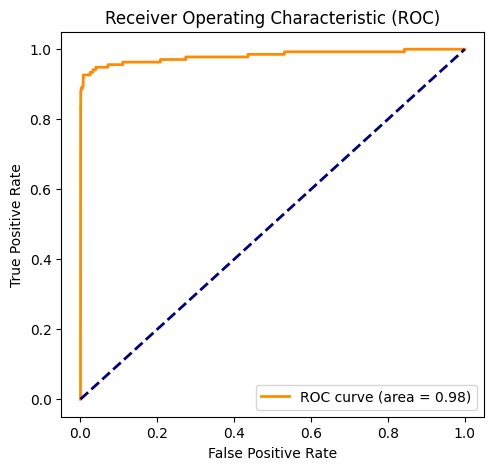

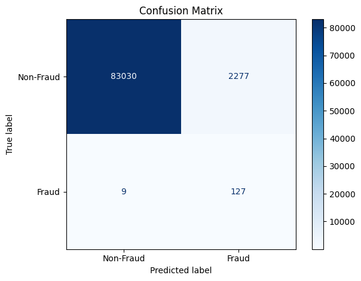

```python
from sklearn.metrics import roc_curve, auc, ConfusionMatrixDisplay
import matplotlib.pyplot as plt

# Gerando probabilidades preditas
y_pred_proba = model.predict_proba(X_test)[:, 1]

# Calculando a Curva ROC e AUC
fpr, tpr, thresholds = roc_curve(y_test, y_pred_proba)
roc_auc = auc(fpr, tpr)

# Calculando a matriz de confusão
conf_matrix = confusion_matrix(y_test, y_pred)

# Plota a Curva ROC
plt.figure(figsize=(12, 5))

plt.subplot(1, 2, 1)
plt.plot(fpr, tpr, color='darkorange', lw=2, label='ROC curve (area = %0.2f)' % roc_auc)
plt.plot([0, 1], [0, 1], color='navy', lw=2, linestyle='--')
plt.xlabel('False Positive Rate')
plt.ylabel('True Positive Rate')
plt.title('Receiver Operating Characteristic (ROC)')
plt.legend(loc="lower right")

# Plota a matriz de confusão
plt.subplot(1, 2, 1)
ConfusionMatrixDisplay(conf_matrix, display_labels=['Non-Fraud', 'Fraud']).plot(cmap=plt.cm.Blues)
plt.title('Confusion Matrix')

plt.tight_layout()
plt.show()
```

## Ajustar os hiperparâmetros

```python
from sklearn.model_selection import GridSearchCV

# Definindo os hiperparâmetros para testar
param_grid = {'C': [0.1, 1, 10, 100], 'penalty': ['l1', 'l2']}

# Criando o objeto GridSearchCV
grid_search = GridSearchCV(LogisticRegression(), param_grid, cv=5, scoring='recall')

# Treinando o modelo com grid search
grid_search.fit(X_train_sm, y_train_sm)

# Verificando os melhores parâmetros
print("Melhores parâmetros:", grid_search.best_params_)
```

[output not shown]

```
Melhores parâmetros: {'C': 100, 'penalty': 'l2'}
```

```python
# Ajustando o modelo com os melhores parâmetros encontrados e aumentando max_iter
model = LogisticRegression(C=100, penalty='l2', max_iter=1000)
model.fit(X_train_sm, y_train_sm)

# Avaliação do modelo ajustado
y_pred_parametrizado = model.predict(X_test)
print(classification_report(y_test, y_pred_parametrizado))
print("Acurácia:", accuracy_score(y_test, y_pred_parametrizado))
print("F1-Score:", f1_score(y_test, y_pred_parametrizado))
print("AUC ROC:", roc_auc_score(y_test, model.predict_proba(X_test)[:, 1]))
```

```
              precision    recall  f1-score   support

           0       1.00      0.97      0.99     85307
           1       0.05      0.93      0.10       136

    accuracy                           0.97     85443
   macro avg       0.53      0.95      0.54     85443
weighted avg       1.00      0.97      0.98     85443

Acurácia: 0.973210210315649
F1-Score: 0.0998820290994888
AUC ROC: 0.9807180846479049
```

# Avaliando com outros modelos

## Árvore de Decisão

```python
from sklearn.tree import DecisionTreeClassifier
from sklearn.metrics import classification_report, accuracy_score, roc_auc_score, f1_score

# Árvore de Decisão
dt_model = DecisionTreeClassifier(random_state=42)
dt_model.fit(X_train_sm, y_train_sm)
y_dt_pred = dt_model.predict(X_test)

print("Modelo: Árvore de Decisão")
print(classification_report(y_test, y_dt_pred))
print("Acurácia:", accuracy_score(y_test, y_dt_pred))
print("F1-Score:", f1_score(y_test, y_dt_pred))
print("AUC ROC:", roc_auc_score(y_test, dt_model.predict_proba(X_test)[:, 1]))
print("\n")
```

```
Modelo: Árvore de Decisão
              precision    recall  f1-score   support

           0       1.00      1.00      1.00     85307
           1       0.36      0.76      0.49       136

    accuracy                           1.00     85443
   macro avg       0.68      0.88      0.75     85443
weighted avg       1.00      1.00      1.00     85443

Acurácia: 0.9974954062942546
F1-Score: 0.4928909952606635
AUC ROC: 0.8812862057385815
```

## Floresta Aleatória

```python
from sklearn.ensemble import RandomForestClassifier
from sklearn.metrics import classification_report, accuracy_score, roc_auc_score, f1_score

# Floresta Aleatória
rf_model = RandomForestClassifier(random_state=42)
rf_model.fit(X_train_sm, y_train_sm)
y_rf_pred = rf_model.predict(X_test)

print("Modelo: Floresta Aleatória")
print(classification_report(y_test, y_rf_pred))
print("Acurácia:", accuracy_score(y_test, y_rf_pred))
print("F1-Score:", f1_score(y_test, y_rf_pred))
print("AUC ROC:", roc_auc_score(y_test, rf_model.predict_proba(X_test)[:, 1]))
print("\n")
```

```
Modelo: Floresta Aleatória
              precision    recall  f1-score   support

           0       1.00      1.00      1.00     85307
           1       0.84      0.87      0.85       136

    accuracy                           1.00     85443
   macro avg       0.92      0.93      0.93     85443
weighted avg       1.00      1.00      1.00     85443

Acurácia: 0.9995201479348805
F1-Score: 0.8519855595667869
AUC ROC: 0.9857927923299861
```

## K-Vizinhos Mais Próximos (KNN)

```python
from sklearn.neighbors import KNeighborsClassifier
from sklearn.metrics import classification_report, accuracy_score, roc_auc_score, f1_score

# K-Vizinhos Mais Próximos (KNN)
knn_model = KNeighborsClassifier()
knn_model.fit(X_train_sm, y_train_sm)
y_knn_pred = knn_model.predict(X_test)

print("Modelo: K-Vizinhos Mais Próximos (KNN)")
print(classification_report(y_test, y_knn_pred))
print("Acurácia:", accuracy_score(y_test, y_knn_pred))
print("F1-Score:", f1_score(y_test, y_knn_pred))
print("AUC ROC:", roc_auc_score(y_test, knn_model.predict_proba(X_test)[:, 1]))
print("\n")
```

```
Modelo: K-Vizinhos Mais Próximos (KNN)
              precision    recall  f1-score   support

           0       1.00      1.00      1.00     85307
           1       0.43      0.90      0.58       136

    accuracy                           1.00     85443
   macro avg       0.71      0.95      0.79     85443
weighted avg       1.00      1.00      1.00     85443

Acurácia: 0.9979167398148473
F1-Score: 0.5781990521327014
AUC ROC: 0.9517031565577335
```

## Naive Bayes Gaussiano

```python
from sklearn.naive_bayes import GaussianNB
from sklearn.metrics import classification_report, accuracy_score, roc_auc_score, f1_score

# Naive Bayes Gaussiano
nb_model = GaussianNB()
nb_model.fit(X_train_sm, y_train_sm)
y_nb_pred = nb_model.predict(X_test)

print("Modelo: Naive Bayes Gaussiano")
print(classification_report(y_test, y_nb_pred))
print("Acurácia:", accuracy_score(y_test, y_nb_pred))
print("F1-Score:", f1_score(y_test, y_nb_pred))
print("AUC ROC:", roc_auc_score(y_test, nb_model.predict_proba(X_test)[:, 1]))
print("\n")
```

```
Modelo: Naive Bayes Gaussiano
              precision    recall  f1-score   support

           0       1.00      0.98      0.99     85307
           1       0.06      0.88      0.11       136

    accuracy                           0.98     85443
   macro avg       0.53      0.93      0.55     85443
weighted avg       1.00      0.98      0.99     85443

Acurácia: 0.9762180635043245
F1-Score: 0.1056338028169014
AUC ROC: 0.9667901451435955
```

## Grafico de Comparação dos modelos

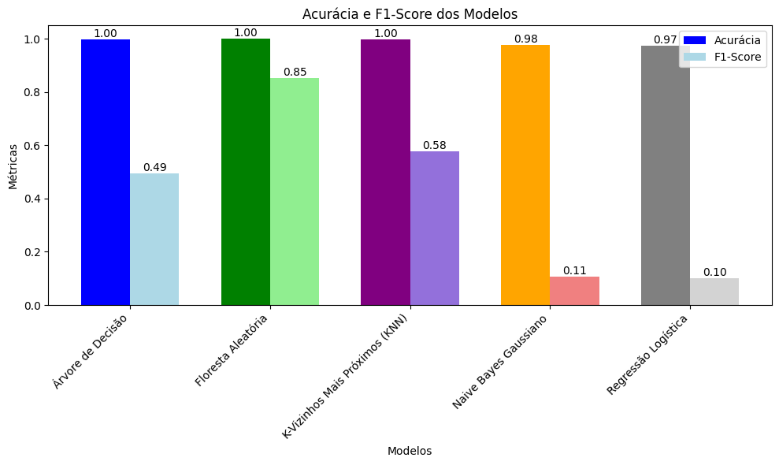

```python
import matplotlib.pyplot as plt
import numpy as np

# Lista de nomes dos modelos (excluindo o SVM)
model_names = ["Árvore de Decisão", "Floresta Aleatória",
              "K-Vizinhos Mais Próximos (KNN)", "Naive Bayes Gaussiano", "Regressão Logística"]

# Lista das métricas correspondentes a cada modelo (acurácia e F1-Score)
accuracies = [accuracy_score(y_test, y_dt_pred), accuracy_score(y_test, y_rf_pred),
              accuracy_score(y_test, y_knn_pred), accuracy_score(y_test, y_nb_pred), accuracy_score(y_test, y_pred)]

f1_scores = [f1_score(y_test, y_dt_pred), f1_score(y_test, y_rf_pred),
             f1_score(y_test, y_knn_pred), f1_score(y_test, y_nb_pred), f1_score(y_test, y_pred)]

# Cores para acurácia e F1-Score
accuracy_colors = ['blue', 'green', 'purple', 'orange', 'gray']
f1_score_colors = ['lightblue', 'lightgreen', 'mediumpurple', 'lightcoral', 'lightgray']

# Crie o gráfico de barras
width = 0.35
x = np.arange(len(model_names))

fig, ax = plt.subplots(figsize=(10, 6))

# Plote as barras de acurácia
ax.bar(x - width/2, accuracies, width, label='Acurácia', color=accuracy_colors)

# Plote as barras de F1-Score
ax.bar(x + width/2, f1_scores, width, label='F1-Score', color=f1_score_colors)

ax.set_xlabel('Modelos')
ax.set_ylabel('Métricas')
ax.set_title('Acurácia e F1-Score dos Modelos')
ax.set_xticks(x)
ax.set_xticklabels(model_names, rotation=45, ha="right")

# Mostrar os valores acima de cada barra (arredondados para 2 casas decimais)
for i, (acc, f1) in enumerate(zip(accuracies, f1_scores)):
    ax.text(x[i] - width/2, acc, f'{acc:.2f}', ha='center', va='bottom')
    ax.text(x[i] + width/2, f1, f'{f1:.2f}', ha='center', va='bottom')

ax.legend()

plt.tight_layout()
plt.show()
```

## Análise dos Modelos em Comparação com a Regressão Logística

### Árvore de Decisão

- **Vantagens:** Pode capturar relações não-lineares e interações complexas entre as variáveis. É fácil de interpretar e explicar.
- **Desvantagens:** Suscetibilidade ao overfitting, particularmente com acurácia de 1.00. Pode não generalizar bem.
- **Análise:** Alta acurácia com baixo F1-Score sugere falha em classificar corretamente a classe minoritária. Não é recomendável substituir a Regressão Logística sem ajustes para evitar overfitting.

### KNN (Vizinhos Mais Próximos)

- **Vantagens:** Simples e eficaz, intuitivo e baseado em instâncias.
- **Desvantagens:** Lentidão em grandes conjuntos de dados e necessidade de normalização cuidadosa.
- **Análise:** Acurácia perfeita pode indicar overfitting, e o F1-Score moderado mostra alguma capacidade, mas não é o melhor modelo.

### Naive Bayes Gaussiano

- **Vantagens:** Simples, rápido e eficaz com independência entre características.
- **Desvantagens:** A suposição de independência raramente é verdadeira.
- **Análise:** Alta acurácia mas baixo F1-Score indica falha na identificação correta de fraudes.

### Regressão Logística

- **Vantagens:** Probabilidades nas previsões, simplicidade, eficácia e boa interpretabilidade.
- **Desvantagens:** Pode não capturar relações complexas eficientemente.
- **Análise:** Alta acurácia com F1-Score baixo mostra deficiência na detecção de fraudes, similar ao Naive Bayes.

**Conclusão:** A Floresta Aleatória surge como uma alternativa superior, especialmente considerando o F1-Score para a classificação desequilibrada. Uma mudança pode aumentar a eficácia do sistema antifraude. Entretanto, é essencial uma análise aprofundada, incluindo validação cruzada e ajuste de hiperparâmetros, antes de efetuar a mudança de modelo.

## Transição de Regressão Logística para Floresta Aleatória

A escolha de migrar do modelo de **Regressão Logística** para **Floresta Aleatória** no projeto DetectAI foi uma decisão estratégica baseada em uma análise meticulosa dos desempenhos dos modelos em questão. Abaixo estão os motivos técnicos que fundamentam essa transição:

### Complexidade dos Dados

A **Regressão Logística**, apesar de sua robustez e interpretabilidade, é limitada em sua capacidade de capturar interações complexas e não-lineares entre as variáveis. A **Floresta Aleatória** supera essa limitação ao incorporar múltiplas Árvores de Decisão que coletivamente modelam a intricada estrutura dos dados, tornando-a mais adequada para o conjunto de dados multifacetado e não-linear do DetectAI.

### Robustez a Variações nos Dados

O procedimento de *bagging* da **Floresta Aleatória** oferece uma resistência considerável a variações, minimizando a variância sem aumentar o viés. Isso é primordial para garantir a acurácia na detecção de fraudes em novos dados e para prevenir o *overfitting*.

### Tratamento de Classes Desequilibradas

O desequilíbrio acentuado entre as classes de transações legítimas e fraudulentas é efetivamente administrado pela **Floresta Aleatória**. A técnica de construir múltiplas árvores a partir de amostras do conjunto de dados proporciona uma atenção equilibrada às classes, especialmente à minoritária, o que é evidenciado por um F1-Score substancialmente melhorado.

### Métricas de Avaliação

O alto F1-Score alcançado pela **Floresta Aleatória** reflete sua capacidade de identificar corretamente as fraudes (elevado *recall*) e de manter os falsos positivos em número reduzido (alta precisão). Este equilíbrio é essencial para limitar os custos operacionais associados ao tratamento de alertas falsos e para manter a confiança dos usuários no sistema.

### Conclusão

A transição para a **Floresta Aleatória** foi impulsionada pela necessidade de um modelo com desempenho superior e maior confiabilidade no sistema preditivo de antifraude do DetectAI. A análise empírica das métricas de desempenho, onde a **Floresta Aleatória** mostrou-se superior à **Regressão Logística**, fornece uma base sólida para essa mudança.

# Criando modelo com Floresta Aleatoria

```python
from sklearn.ensemble import RandomForestClassifier
from sklearn.model_selection import train_test_split
from sklearn.preprocessing import StandardScaler
import joblib
import pandas as pd

# Separar as características e o alvo
X = df.drop('Class', axis=1)
y = df['Class']

# Dividir os dados em conjuntos de treinamento e teste
X_train, X_test, y_train, y_test = train_test_split(X, y, test_size=0.3, random_state=42)

# Inicializar o StandardScaler
scaler = StandardScaler()

# Ajustar o scaler apenas com os dados de treinamento e transformar os conjuntos de treino e teste
X_train_scaled = scaler.fit_transform(X_train)
X_test_scaled = scaler.transform(X_test)

# Inicializar o modelo de Floresta Aleatória com parâmetros genéricos
rf_classifier = RandomForestClassifier(
    n_estimators=100,
    max_depth=None,
    min_samples_split=2,
    min_samples_leaf=1,
    max_features='auto',
    bootstrap=True,
    random_state=42
)

# Treinar o modelo de Floresta Aleatória com os dados de treino escalados
rf_classifier.fit(X_train_scaled, y_train)
```

```
RandomForestClassifier(max_features='auto', random_state=42)
```

```python
# Salvar o modelo e o scaler no diretório local do Colab
model_save_path = '/content/rf_classifier.joblib'
scaler_save_path = '/content/scaler.joblib'
joblib.dump(rf_classifier, model_save_path)
joblib.dump(scaler, scaler_save_path)

print(f"Modelo salvo em: {model_save_path}")
print(f"Scaler salvo em: {scaler_save_path}")
```

```
Modelo salvo em: /content/rf_classifier.joblib
Scaler salvo em: /content/scaler.joblib
```

```
Classificação do Relatório:
              precision    recall  f1-score   support

           0       1.00      1.00      1.00     85307
           1       0.88      0.77      0.82       136

    accuracy                           1.00     85443
   macro avg       0.94      0.89      0.91     85443
weighted avg       1.00      1.00      1.00     85443

Acurácia: 0.9994616293903538
```

```
AUC ROC: 0.9585859532249957
```

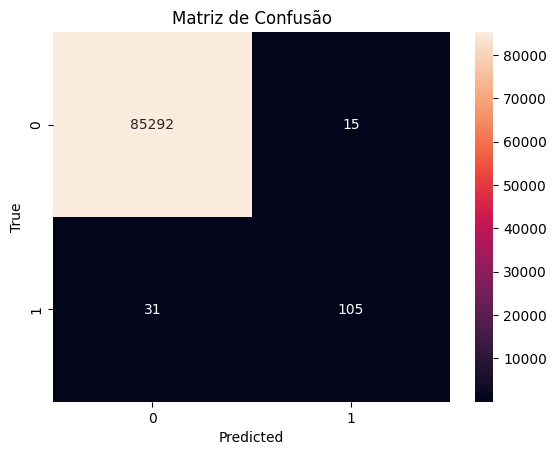

```python
from sklearn.metrics import classification_report, accuracy_score, confusion_matrix, roc_auc_score
import matplotlib.pyplot as plt
import seaborn as sns

# Fazer previsões no conjunto de teste
y_pred = rf_classifier.predict(X_test)

# Avaliar o modelo
print("Classificação do Relatório:")
print(classification_report(y_test, y_pred))
print("Acurácia:", accuracy_score(y_test, y_pred))
print("AUC ROC:", roc_auc_score(y_test, rf_classifier.predict_proba(X_test)[:, 1]))

# Matriz de Confusão
conf_matrix = confusion_matrix(y_test, y_pred)
sns.heatmap(conf_matrix, annot=True, fmt='g')
plt.xlabel('Predicted')
plt.ylabel('True')
plt.title('Matriz de Confusão')
plt.show()
```